# Capstone Project - Los Angeles Motor Traffic Collisions during Year 2018 (Week 2)

### IBM Data Science Capstone by IBM/Coursera

- Introduction: Business Problem
- Data
- Exploratory Data Analysis
- Methodology
- Analysis
- Results and Discussion
- Conclusion

## Introduction: Business Problem

In this use case, lets analyze Los Angeles traffic collision data and identify & cluster similar venue categories near to the collision locations. So that LA Dept of Transportation authorities can better understand the public needs and plan accordingly to ease up traffic congestions in each locality around the popular venues, which will help in minimizing the traffic collision rates.

**Background**

Los Angeles has one of the highest motor collision rate among United States metropolitan cities.

Los Angeles traffic congestion is also rated as one of the highest in United States and probably in the world. Even though, LA has mass public transport system including public buses, light Rail and subway, ridership rates are decreasing annually and residents are taking on to roads to move around the city, which is resulting in high fatality collision rates.

There are several contributing factors for high collision rates like increasing population rates, aging public transit infrastructure, increasing economy, popular venues or events etc.

Popular venues may inadverently contributes to traffic congestions and collisions. Popular venues includes music arenas, parks, cafes, yoga studios etc. Analyzing venues near to collision locations helps in understanding traffic footnote and public needs. Thus helping LA Dept of Transportation to plan better in order to ease up congestions and minimize collisions.

## Data

Under open data policy, **LAPD** (Los Angeles Police Department) collects and regularly updates Los Angeles traffic collision data every week.

**Following are the data sources:**

- Los Angeles traffic collision data is provided in LA city open data website.  
  https://data.lacity.org/A-Safe-City/Traffic-Collision-Data-from-2010-to-Present/d5tf-ez2w
- Los Angeles Police Department reporting divisions geo location data is provided in LA Times website for open use.  
  http://boundaries.latimes.com/1.0/boundary-set/lapd-divisions/?format=geojson
- Venues and venue categories data wil be obained from **Foursquare API** using their APIs.  
  Foursquare API endpoint to fetch recommended venues https://api.foursquare.com/v2/venues/explore  
  Foursquare API endpoint to fetch transport venues https://api.foursquare.com/v2/venues/search

**Following are the observations made about the collision data provided to the public:**

- Los Angeles traffic collision data is provided from year 2010 to till current date.
- Data is provided in various formats like csv, json (via api) etc.
- Provided data is sanitized to scrub all PII (personally identifiable information).
- Geo location coordinates are provided for all collisions.

**Data Consumption is done the following way:**

- Los Angeles traffic collision data will be read in csv format.
- Los Angeles police reporting divisions data will be read in geojson format.
- Foursquare Venue exploration data will be read in json format.

**Data Usage is done the following way:**

- Los Angeles traffic collision data for year 2018 will be used to analyze the collisions.
- Collision geo location coordinates will be used as input to obtain nearby venue data from Foursquare.
- Obtained Foursquare venue data will be used to cluster collision locations
- LAPD reporting divisions geo json data will be used for choropleth maps.

## Exploratory Data Analysis

```python
# import all needed libraries

from bs4 import BeautifulSoup
import requests
import pandas as pd
pd.set_option('display.max_columns', None)
pd.set_option('display.max_rows', None)
import numpy as np # library to handle data in a vectorized manner

import json # library to handle JSON files
from pandas.io.json import json_normalize # tranform JSON file into a pandas dataframe

#!conda install -c conda-forge folium=0.5.0 --yes # uncomment this line if you haven't completed the Foursquare API lab
import folium # map rendering library
from folium.plugins import MarkerCluster

# Matplotlib and associated plotting modules
import matplotlib.cm as cm
import matplotlib.pyplot as plt
import matplotlib.dates as mdates
import matplotlib.colors as colors
import seaborn as sns

# import k-means from clustering stage
from sklearn.cluster import KMeans
from scipy.spatial.distance import cdist

# split feature and dependent arrays into train and test arrays
from sklearn.model_selection import train_test_split
import sklearn.utils
from sklearn.datasets.samples_generator import make_blobs
from sklearn.preprocessing import StandardScaler
```

#### Read LA Traffic Collision Data

```python
la_collision_raw = pd.read_csv("https://data.lacity.org/api/views/d5tf-ez2w/rows.csv?accessType=DOWNLOAD")
```

```python
# print shape of read data to know the number of rows and columns in dataframe
print(la_collision_raw.shape)
la_collision_raw.head()
```

```
(466242, 24)
```

|  | DR Number | Date Reported | Date Occurred | Time Occurred | Area ID | Area Name | Reporting District | Crime Code | Crime Code Description | MO Codes | Victim Age | Victim Sex | Victim Descent | Premise Code | Premise Description | Address | Cross Street | Location | Zip Codes | Census Tracts | Precinct Boundaries | LA Specific Plans | Council Districts | Neighborhood Councils (Certified) |
| --- | --- | --- | --- | --- | --- | --- | --- | --- | --- | --- | --- | --- | --- | --- | --- | --- | --- | --- | --- | --- | --- | --- | --- | --- |
| 0 | 190408788 | 04/20/2019 | 04/20/2019 | 1020 | 4 | Hollenbeck | 429 | 997 | TRAFFIC COLLISION | NaN | 41.0 | F | O | 101.0 | STREET | MARNEY | DRUCKER | (34.0865, -118.1647) | 23449.0 | 502.0 | 609.0 | NaN | 9.0 | 91.0 |
| 1 | 190709454 | 04/20/2019 | 04/20/2019 | 1250 | 7 | Wilshire | 701 | 997 | TRAFFIC COLLISION | NaN | 27.0 | F | W | 101.0 | STREET | LA CIENEGA BL | MELROSE PL | (34.0836, -118.3765) | 24034.0 | 461.0 | 801.0 | NaN | 6.0 | 26.0 |
| 2 | 191109241 | 04/20/2019 | 04/20/2019 | 900 | 11 | Northeast | 1184 | 997 | TRAFFIC COLLISION | 0605 | 18.0 | M | X | 101.0 | STREET | MORTON AV | ECHO PARK AV | (34.081, -118.2547) | 23444.0 | 481.0 | 254.0 | NaN | 8.0 | 31.0 |
| 3 | 190808715 | 04/20/2019 | 04/20/2019 | 1110 | 8 | West LA | 836 | 997 | TRAFFIC COLLISION | NaN | 25.0 | M | B | 108.0 | PARKING LOT | SANTA MONICA BL | THAYER AV | (34.0557, -118.427) | 23442.0 | 858.0 | 501.0 | 9.0 | 6.0 | 72.0 |
| 4 | 190909546 | 04/20/2019 | 04/20/2019 | 655 | 9 | Van Nuys | 914 | 997 | TRAFFIC COLLISION | NaN | 58.0 | M | B | 101.0 | STREET | VAN NUYS | SHERMAN | (34.2012, -118.4487) | 19733.0 | 215.0 | 880.0 | NaN | 5.0 | 18.0 |

```python
# Rename all column names to replace spaces in the between the words of column names
cols=[]
cols = list(la_collision_raw.columns)
for idx, col in enumerate(cols):
    cols[idx]=col.replace(' ','_')
la_collision_raw.columns=cols
la_collision_raw.columns
```

```
Index(['DR_Number', 'Date_Reported', 'Date_Occurred', 'Time_Occurred',
       'Area_ID', 'Area_Name', 'Reporting_District', 'Crime_Code',
       'Crime_Code_Description', 'MO_Codes', 'Victim_Age', 'Victim_Sex',
       'Victim_Descent', 'Premise_Code', 'Premise_Description', 'Address',
       'Cross_Street', 'Location', 'Zip_Codes', 'Census_Tracts',
       'Precinct_Boundaries', 'LA_Specific_Plans', 'Council_Districts',
       'Neighborhood_Councils_(Certified)'],
      dtype='object')
```

```python
# Print data types of all features
la_collision_raw.dtypes
```

```
DR_Number                              int64
Date_Reported                         object
Date_Occurred                         object
Time_Occurred                          int64
Area_ID                                int64
Area_Name                             object
Reporting_District                     int64
Crime_Code                             int64
Crime_Code_Description                object
MO_Codes                              object
Victim_Age                           float64
Victim_Sex                            object
Victim_Descent                        object
Premise_Code                         float64
Premise_Description                   object
Address                               object
Cross_Street                          object
Location                              object
Zip_Codes                            float64
Census_Tracts                        float64
Precinct_Boundaries                  float64
LA_Specific_Plans                    float64
Council_Districts                    float64
Neighborhood_Councils_(Certified)    float64
dtype: object
```

```python
# Drop all null data
la_collision_fmt=la_collision_raw[['Date_Reported','Date_Occurred','Time_Occurred','Area_Name',
                                   'Victim_Age','Victim_Sex','Victim_Descent','Premise_Description','Address',
                                   'Location']].dropna().reset_index(drop=True)
la_collision_fmt.shape
```

```
(388972, 10)
```

```python
# Format features like dates, times and convert columns into integer type.
# Replace values of feature Victim_Descent and split Location into two features Latitude & Longitude
la_collision_fmt['Date_Reported']=pd.to_datetime(la_collision_fmt.Date_Reported)
la_collision_fmt['Date_Occurred']=pd.to_datetime(la_collision_fmt.Date_Occurred)
la_collision_fmt['Time_Occurred']=la_collision_fmt.Time_Occurred.astype(str).str.pad(width=4, side='left', fillchar='0')
la_collision_fmt['Victim_Age']=la_collision_fmt.Victim_Age.astype(int)
la_collision_fmt.replace({'Victim_Descent':{'H':'Hispanic','B':'Black','O':'Other','W':'White','X':'Unknown','A':'Asian',
                                            'K':'Korean','C':'Chinese','F':'Filipino','U':'Hawaiian','J':'Japanese',
                                            'P':'Pacific Islanders','V':'Vietnamese','Z':'Asian Indian',
                                            'I':'American Indian','G':'Guamanian','S':'Samoan','D':'Cambodian',
                                            'L':'Laotian','-':'Unknown'}}, inplace=True)
la_collision_fmt[['Latitude','Longitude']]=la_collision_fmt.Location.str.replace('(','').str.replace(')','').str.split(',',n=1,expand=True)
la_collision_fmt.drop(['Location'], axis=1, inplace=True)
```

```python
la_collision_fmt.head()
```

|  | Date_Reported | Date_Occurred | Time_Occurred | Area_Name | Victim_Age | Victim_Sex | Victim_Descent | Premise_Description | Address | Latitude | Longitude |
| --- | --- | --- | --- | --- | --- | --- | --- | --- | --- | --- | --- |
| 0 | 2019-04-20 | 2019-04-20 | 1020 | Hollenbeck | 41 | F | Other | STREET | MARNEY | 34.0865 | -118.1647 |
| 1 | 2019-04-20 | 2019-04-20 | 1250 | Wilshire | 27 | F | White | STREET | LA CIENEGA BL | 34.0836 | -118.3765 |
| 2 | 2019-04-20 | 2019-04-20 | 0900 | Northeast | 18 | M | Unknown | STREET | MORTON AV | 34.081 | -118.2547 |
| 3 | 2019-04-20 | 2019-04-20 | 1110 | West LA | 25 | M | Black | PARKING LOT | SANTA MONICA BL | 34.0557 | -118.427 |
| 4 | 2019-04-20 | 2019-04-20 | 0655 | Van Nuys | 58 | M | Black | STREET | VAN NUYS | 34.2012 | -118.4487 |

#### Plot line graph for Collision Year vs Collisions count

##### To navigate back to results section Click Here

```
Year Collisions_Count
2010    37554
2011    38226
2012    38411
2013    37424
2014    39107
2015    42994
2016    46822
2017    47990
2018    47719
2019    12725
Name: Date_Occurred, dtype: int64
```

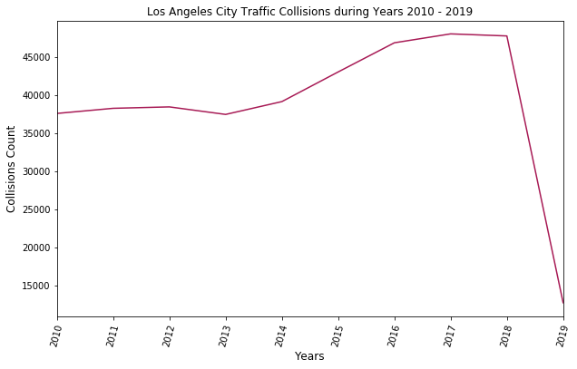

```python
# Plot line graph for data Collision Year vs Collisions count
print('Year','Collisions_Count \n' + str(la_collision_fmt.Date_Occurred.dt.year.value_counts().sort_index()))
la_collision_fmt.Date_Occurred.dt.year.value_counts().sort_index().plot(
    kind='line',figsize=(10, 6),rot=75,alpha=0.9,colormap=cm.get_cmap('Spectral'),
    title='Los Angeles City Traffic Collisions during Years 2010 - 2019')
plt.xlabel('Years', fontdict={'fontsize': 12})
plt.ylabel('Collisions Count', fontdict={'fontsize': 12})
```

```python
# Since we are anlyzing only for year 2018, filter data and capture collisions occured in year 2018
la_collision_fmt=la_collision_fmt[(la_collision_fmt.Date_Occurred.dt.year==2018) & (la_collision_fmt.Victim_Sex.isin(['M','F']))].reset_index(drop=True)
print(la_collision_fmt.shape)
la_collision_fmt.head()
```

```
(47569, 11)
```

|  | Date_Reported | Date_Occurred | Time_Occurred | Area_Name | Victim_Age | Victim_Sex | Victim_Descent | Premise_Description | Address | Latitude | Longitude |
| --- | --- | --- | --- | --- | --- | --- | --- | --- | --- | --- | --- |
| 0 | 2018-12-31 | 2018-12-31 | 1445 | Southwest | 27 | M | Hispanic | STREET | S BUDLONG | 34.0109 | -118.2959 |
| 1 | 2018-12-31 | 2018-12-31 | 1515 | Hollywood | 30 | F | White | PARKING LOT | SUNSET BL | 34.098 | -118.3267 |
| 2 | 2018-12-31 | 2018-12-31 | 1515 | West LA | 54 | F | Other | STREET | NATIONAL BL | 34.0329 | -118.3832 |
| 3 | 2018-12-31 | 2018-12-31 | 0850 | Van Nuys | 22 | F | Hispanic | STREET | VANOWEN ST | 34.194 | -118.4312 |
| 4 | 2018-12-31 | 2018-12-31 | 2210 | Southeast | 20 | F | Hispanic | STREET | AVALON BL | 33.9402 | -118.2652 |

#### Plot line graph for Area (LAPD Divisions) vs Collisions count

##### To navigate back to results section Click Here

```
Area_Name    Collisions_Count
77th Street    3145
Southwest      2807
Wilshire       2794
Pacific        2624
Newton         2613
Olympic        2554
Van Nuys       2417
West Valley    2391
N Hollywood    2326
Devonshire     2313
West LA        2272
Hollywood      2163
Topanga        2144
Mission        2123
Central        2120
Northeast      1997
Southeast      1907
Rampart        1903
Foothill       1712
Hollenbeck     1698
Harbor         1546
Name: Area_Name, dtype: int64
```

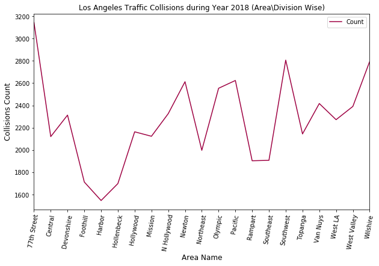

```python
# Plot line graph for data Area (LAPD Divisions) vs Collisions count
print('Area_Name','   Collisions_Count \n' + str(la_collision_fmt['Area_Name'].value_counts()))
la_collision_fmt['Area_Name'].value_counts().sort_index().to_frame('Count').plot(figsize=(10, 6),rot=80,use_index=True,
                colormap=cm.get_cmap('Spectral'),
                title='Los Angeles Traffic Collisions during Year 2018 (Area\Division Wise)')
areanm=np.sort(la_collision_fmt['Area_Name'].unique())
x_idx=np.arange(len(areanm))
plt.xticks(x_idx, areanm)
plt.xlabel('Area Name', fontdict={'fontsize': 12})
plt.ylabel('Collisions Count', fontdict={'fontsize': 12})
```

#### Plot line graph for data Victim Descent vs Collisions count

##### To navigate back to resuts section Click Here

```
Victim_Descent  Collisions_Count
Hispanic             19771
White                10753
Black                 7053
Other                 6272
Asian                 1924
Unknown               1074
Korean                 366
Filipino               152
Chinese                 71
Japanese                25
Hawaiian                22
Vietnamese              22
Pacific Islanders       20
Asian Indian            19
American Indian         18
Guamanian                5
Cambodian                1
Samoan                   1
Name: Victim_Descent, dtype: int64
```

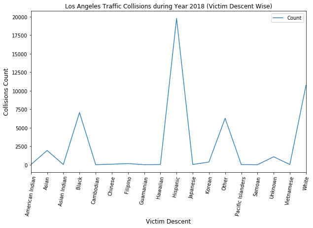

```python
# Plot line graph for data Victim Descent vs Collisions count
print('Victim_Descent',' Collisions_Count \n' + str(la_collision_fmt['Victim_Descent'].value_counts()))
la_collision_fmt['Victim_Descent'].value_counts().sort_index().to_frame('Count').plot(kind='line',
                figsize=(10, 6),rot=80,
                use_index=True,
                alpha=0.9,
                title='Los Angeles Traffic Collisions during Year 2018 (Victim Descent Wise)')
vic_descent=np.sort(la_collision_fmt['Victim_Descent'].unique())
x_idx=np.arange(len(vic_descent))
plt.xticks(x_idx, vic_descent)
plt.xlabel('Victim Descent', fontdict={'fontsize': 12})
plt.ylabel('Collisions Count', fontdict={'fontsize': 12})
```

#### Plot line graph for Month vs Collisions count

##### To navigate back to results section Click Here

```
Month Collisions_Count
1     3834
2     3713
3     4099
4     3873
5     3785
6     3866
7     4092
8     4131
9     3954
10    4389
11    3974
12    3859
Name: Date_Occurred, dtype: int64
```

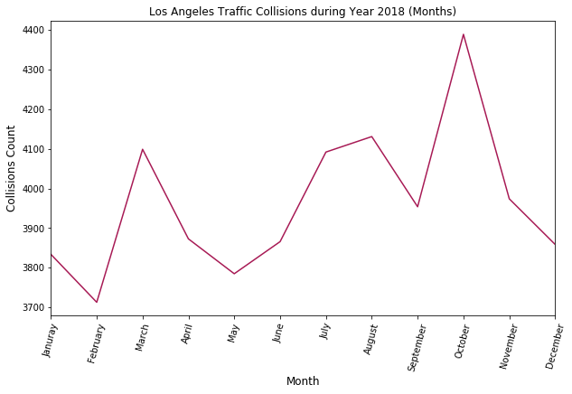

```python
# Plot line graph for data Month (Collision Occured) vs Collisions count
print('Month','Collisions_Count \n' + str(la_collision_fmt.Date_Occurred.dt.month.value_counts().sort_index()))
la_collision_fmt.Date_Occurred.dt.month.value_counts().sort_index().rename(
{1:'January',2:'February',3:'March',4:'April',5:'May',6:'June',7:'July',
 8:'August',9:'September',10:'October',11:'November',12:'December'}).plot(
    kind='line',figsize=(10, 6),rot=75,alpha=0.9,colormap=cm.get_cmap('Spectral'),
    title='Los Angeles Traffic Collisions during Year 2018 (Months)')
months=np.array(['Januray','February','March','April','May','June','July','August','September','October','November','December'])
x_idx=np.arange(len(months))
plt.xticks(x_idx, months)
plt.xlabel('Month', fontdict={'fontsize': 12})
plt.ylabel('Collisions Count', fontdict={'fontsize': 12})
```

#### Plot line graph for Week day vs Collisions count

##### To navigate back to results section Click Here

```
Week_Day Collisions_Count
0    6816
1    6855
2    6928
3    7080
4    7572
5    6464
6    5854
Name: Date_Occurred, dtype: int64
```

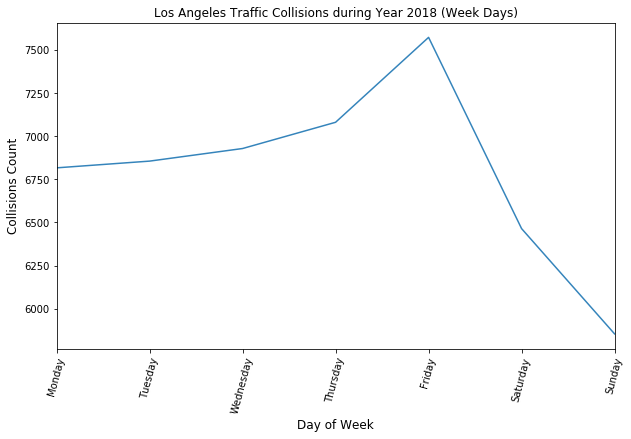

```python
# Plot line graph for data Week day vs Collisions count
print('Week_Day','Collisions_Count \n' + str(la_collision_fmt.Date_Occurred.dt.dayofweek.value_counts().sort_index()))
la_collision_fmt.Date_Occurred.dt.dayofweek.value_counts().sort_index().rename(
    {0:'Monday',1:'Tuesday',2:'Wednesday',3:'Thursday',4:'Friday',5:'Saturday',6:'Sunday'}).plot(kind='line',
    figsize=(10, 6),rot=75,alpha=0.9,title=('Los Angeles Traffic Collisions during Year 2018 (Week Days)'))
plt.xlabel('Day of Week', fontdict={'fontsize': 12})
plt.ylabel('Collisions Count', fontdict={'fontsize': 12})
```

#### Plot line graph for Time vs Collisions count

##### To navigate back to results section Click Here

```
Time(Hrs) Collisions_Count
00    1048
01     856
02     820
03     485
04     410
05     598
06    1091
07    2177
08    2435
09    2199
10    2214
11    2293
12    2676
13    2766
14    3001
15    3143
16    3135
17    3400
18    3071
19    2585
20    2202
21    1965
22    1623
23    1376
Name: Time_Occurred, dtype: int64
```

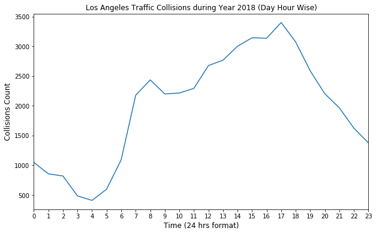

```python
# Plot line graph for data Time vs Collisions count
print('Time(Hrs)','Collisions_Count \n' + str(la_collision_fmt.Time_Occurred.str.slice(start=0, stop=2).value_counts().sort_index()))
la_collision_fmt.Time_Occurred.str.slice(start=0, stop=2).value_counts().sort_index().plot(kind='line',
            figsize=(10, 6),title='Los Angeles Traffic Collisions during Year 2018 (Day Hour Wise)')
hours=np.arange(0,24)
x_idx=np.arange(0,24)
plt.xticks(x_idx, hours)
plt.xlabel('Time (24 hrs format)', fontdict={'fontsize': 12})
plt.ylabel('Collisions Count', fontdict={'fontsize': 12})
```

##### To navigate back to results section Click Here

```
Victim_Sex Collisions_Count
M    28198
F    19371
Name: Victim_Sex, dtype: int64
```

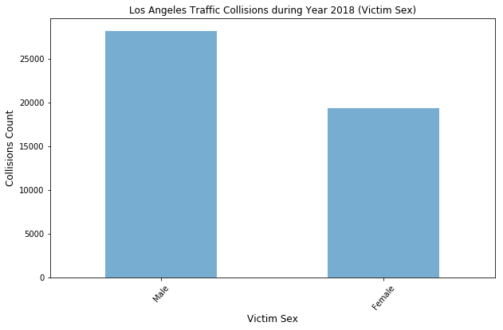

```python
# Plot line graph for data Victim sex vs Collisions count
print('Victim_Sex','Collisions_Count \n' + str(la_collision_fmt['Victim_Sex'].value_counts()))
la_collision_fmt['Victim_Sex'].value_counts().rename({'M':'Male','F':'Female'}).plot(kind='bar',
    rot=50,alpha=0.6,figsize=(10, 6),
    title='Los Angeles Traffic Collisions during Year 2018 (Victim Sex)')
plt.xlabel('Victim Sex', fontdict={'fontsize': 12})
plt.ylabel('Collisions Count', fontdict={'fontsize': 12})
```

```python
# Format Victim age to put them in bins
# For example, if victim age is 25, that victim will be placed in bin or group 'Age_21_30'
# Also create bins to victim age data to be placed in.
la_collision_binfmt=la_collision_fmt[['Victim_Age','Victim_Sex']]
bins = np.linspace(min(la_collision_binfmt['Victim_Age']), max(la_collision_binfmt['Victim_Age']), 10)
bin_names = ['Age_15_20', 'Age_21_30', 'Age_31_40', 'Age_41_50', 'Age_51_60', 'Age_61_70', 'Age_71_80', 'Age_81_90', 'Age_91_100']
la_collision_binfmt['Victim_Age_Bin'] = pd.cut(la_collision_binfmt['Victim_Age'], bins, labels=bin_names, include_lowest=True)
la_collision_binfmt.replace({'Victim_Sex':{0:'M',1:'F'}},inplace=True)
```

#### Plot line graph for Victim Age bins Vs Collision count

##### To navigate back to results section Click Here

```
   Victim_Age_Bin Victim_Sex  Count
0       Age_15_20          F   1219
1       Age_15_20          M   1642
2       Age_21_30          F   5885
3       Age_21_30          M   7888
4       Age_31_40          F   4042
5       Age_31_40          M   5825
6       Age_41_50          F   3505
7       Age_41_50          M   5287
8       Age_51_60          F   2452
9       Age_51_60          M   3861
10      Age_61_70          F   1506
11      Age_61_70          M   2239
12      Age_71_80          F    511
13      Age_71_80          M    717
14      Age_81_90          F    149
15      Age_81_90          M    249
16     Age_91_100          F    102
17     Age_91_100          M    490
```

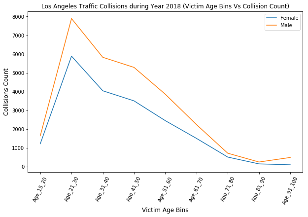

```python
# Place Victims into created bins and plot the line graph for data Victim Age bins Vs Collision count
la_collision_bininfo=la_collision_binfmt.groupby(['Victim_Age_Bin','Victim_Sex']).count().reset_index()
la_collision_bininfo.columns=['Victim_Age_Bin','Victim_Sex','Count']
print(la_collision_bininfo)
la_collision_binx=la_collision_bininfo['Victim_Age_Bin'].unique().to_list()
la_collision_binyF=la_collision_bininfo[la_collision_bininfo['Victim_Sex']=='F']['Count'].to_list()
la_collision_binyM=la_collision_bininfo[la_collision_bininfo['Victim_Sex']=='M']['Count'].to_list()
fig, ax = plt.subplots(figsize=(10, 6))
ax.plot(la_collision_binx, la_collision_binyF, label='Female')
ax.plot(la_collision_binx, la_collision_binyM, label='Male')
ax.legend()
ax.set_title('Los Angeles Traffic Collisions during Year 2018 (Victim Age Bins Vs Collision Count)')
plt.xlabel('Victim Age Bins', fontdict={'fontsize': 12})
plt.ylabel('Collisions Count', fontdict={'fontsize': 12})
plt.xticks(rotation=65)
plt.show()
```

## Methodology

In exploratory data anyalsis, it can be observed that Los Angeles collision data is available from year 2010 to till date. For further analysis, lets consider data only for year 2018 (47K rows).

As part of exploratory data analysis, null data has been filtered and discarded. All possible relations between features are explored and understood. Its worth exploring further with features Area_Name, Victim_Age bins, Victim_Sex, Victim_Descents, Latitude and Longitude.

Foursquare API will be used to compile a list of all near by recommeded venues to the collision locations with in **radius of 500 meters**. And then find out **most frequent recommended venues near to those collision locations**. These most frequent recommended venues might be one of the inadvertent causes for more traffic which may led to collisions and congestions. Please note that due to limited restricted usage of Foursqaure API, only 5 collision locations will be selected per LAPD division or Area_Name for exploration of nearby venues.

**And also use Foursquare API to compile a list of all public transport venues with in radius of 500 meters of the collision locations. Public transport is one of the options available to public in order to avoid traffic congestions and collisions, provided they are with in the range of most frequented venues.**

Finally, report top most 5 recommended venues per collision location and all public transport venues available near to the collision location with in the radius of 500 meters for the public to make avail of them. So that, LA department of transportation can make use of above reported data and arrange more public transport venues near to the most frequented collision locations.

## Analysis

#### Convert Categorical features to numerical values

```python
# Lets convert Victim_Sex categorical values M (male) to 0 and F (female) to 1.
la_collision_fmt['Victim_Sex'].replace(to_replace=['M','F'], value=[0,1],inplace=True)
la_collision_fmt.head()
```

|  | Date_Reported | Date_Occurred | Time_Occurred | Area_Name | Victim_Age | Victim_Sex | Victim_Descent | Premise_Description | Address | Latitude | Longitude |
| --- | --- | --- | --- | --- | --- | --- | --- | --- | --- | --- | --- |
| 0 | 2018-12-31 | 2018-12-31 | 1445 | Southwest | 27 | 0 | Hispanic | STREET | S BUDLONG | 34.0109 | -118.2959 |
| 1 | 2018-12-31 | 2018-12-31 | 1515 | Hollywood | 30 | 1 | White | PARKING LOT | SUNSET BL | 34.098 | -118.3267 |
| 2 | 2018-12-31 | 2018-12-31 | 1515 | West LA | 54 | 1 | Other | STREET | NATIONAL BL | 34.0329 | -118.3832 |
| 3 | 2018-12-31 | 2018-12-31 | 0850 | Van Nuys | 22 | 1 | Hispanic | STREET | VANOWEN ST | 34.194 | -118.4312 |
| 4 | 2018-12-31 | 2018-12-31 | 2210 | Southeast | 20 | 1 | Hispanic | STREET | AVALON BL | 33.9402 | -118.2652 |

```python
# Normalize collision count frequency by Victim_Descent and Area_Name.
# It shows the frequency of collisions per each victim descent per each area name.
la_collision_fmt.groupby(['Victim_Descent'])['Area_Name'].value_counts(normalize=True).to_frame('Frequency')
```

| Victim_Descent | Area_Name | Frequency |
| --- | --- | --- |
| American Indian | Pacific | 0.222222 |
|  | Central | 0.166667 |
|  | Rampart | 0.166667 |
|  | Mission | 0.111111 |
|  | N Hollywood | 0.111111 |
|  | Devonshire | 0.055556 |
|  | Harbor | 0.055556 |
|  | Topanga | 0.055556 |
|  | Van Nuys | 0.055556 |
| Asian | Olympic | 0.160603 |
|  | Wilshire | 0.076403 |
|  | West LA | 0.072765 |
|  | Central | 0.070166 |
|  | Pacific | 0.063410 |
|  | Rampart | 0.060811 |
|  | Devonshire | 0.059771 |
|  | Hollywood | 0.049896 |
|  | West Valley | 0.045218 |
|  | Northeast | 0.044179 |
|  | Southwest | 0.040541 |
|  | Topanga | 0.038462 |
|  | Newton | 0.035343 |
|  | Hollenbeck | 0.031705 |
|  | Van Nuys | 0.030665 |
|  | Mission | 0.030146 |
|  | Harbor | 0.027547 |
|  | N Hollywood | 0.027027 |
|  | Foothill | 0.013514 |
|  | 77th Street | 0.012474 |
|  | Southeast | 0.009356 |

[output cut: 220 more lines]

```python
#### Use binning technique to bin victim age
la_collision_fmt2 = la_collision_fmt[['Area_Name','Address','Latitude','Longitude','Victim_Age','Victim_Sex','Victim_Descent']]
la_collision_fmt2['Victim_Age_Bin'] = pd.cut(la_collision_fmt2['Victim_Age'], bins, labels=bin_names, include_lowest=True )
la_collision_fmt2.drop(['Victim_Age'], axis=1, inplace=True)
print(la_collision_fmt2.shape)
la_collision_fmt2.head()
```

```
(47569, 7)
```

|  | Area_Name | Address | Latitude | Longitude | Victim_Sex | Victim_Descent | Victim_Age_Bin |
| --- | --- | --- | --- | --- | --- | --- | --- |
| 0 | Southwest | S BUDLONG | 34.0109 | -118.2959 | 0 | Hispanic | Age_21_30 |
| 1 | Hollywood | SUNSET BL | 34.098 | -118.3267 | 1 | White | Age_21_30 |
| 2 | West LA | NATIONAL BL | 34.0329 | -118.3832 | 1 | Other | Age_51_60 |
| 3 | Van Nuys | VANOWEN ST | 34.194 | -118.4312 | 1 | Hispanic | Age_15_20 |
| 4 | Southeast | AVALON BL | 33.9402 | -118.2652 | 1 | Hispanic | Age_15_20 |

```python
# Since Foursquare free API calls are limited to 950 calls per day, limit traffic collision data 5 per each unique lapd division/area names.
la_collision_area_unique=la_collision_fmt2.Area_Name.unique()
la_collision_fmt3=pd.DataFrame()
la_collision_fmt2.sort_values(by=['Area_Name','Address'],inplace=True)
for aname in la_collision_area_unique:
    df_temp = la_collision_fmt2[(la_collision_fmt2['Area_Name']==aname)].head(5)  # max 20 rows will be appended per area name
    la_collision_fmt3 = la_collision_fmt3.append(df_temp, ignore_index=True)
la_collision_fmt3.head(10)
```

|  | Area_Name | Address | Latitude | Longitude | Victim_Sex | Victim_Descent | Victim_Age_Bin |
| --- | --- | --- | --- | --- | --- | --- | --- |
| 0 | Southwest | 1000 W 39TH ST | 34.0155 | -118.2915 | 0 | Hispanic | Age_21_30 |
| 1 | Southwest | 1000 W 43RD ST | 34.0055 | -118.2915 | 1 | Unknown | Age_31_40 |
| 2 | Southwest | 1000 W MARTIN LUTHER KING JR BL | 34.0145 | -118.2937 | 1 | Black | Age_31_40 |
| 3 | Southwest | 1000 W MARTIN LUTHER KING JR BL | 34.0109 | -118.2915 | 0 | Hispanic | Age_21_30 |
| 4 | Southwest | 1000 W MARTIN LUTHER KING JR BL | 34.0109 | -118.2915 | 0 | Other | Age_61_70 |
| 5 | Hollywood | 1000 N HIGHLAND AV | 34.0889 | -118.3386 | 0 | Other | Age_61_70 |
| 6 | Hollywood | 1100 N WESTERN AV | 34.0944 | -118.3125 | 0 | Black | Age_21_30 |
| 7 | Hollywood | 1200 N CAHUENGA BL | 34.0926 | -118.3289 | 1 | Unknown | Age_21_30 |
| 8 | Hollywood | 1400 BELFAST DR | 34.096 | -118.3812 | 0 | Black | Age_41_50 |
| 9 | Hollywood | 1400 VINE ST | 34.0962 | -118.3266 | 1 | Other | Age_31_40 |

```python
#### Use one hot encoding technique to convert categorical varables to binary variables and append them to the new DataFrame
la_collision_fmt3 = pd.concat([la_collision_fmt3,pd.get_dummies(la_collision_fmt3['Victim_Age_Bin'])], axis=1)
la_collision_fmt3 = pd.concat([la_collision_fmt3,pd.get_dummies(la_collision_fmt3['Victim_Descent'])], axis=1)
la_collision_fmt3.drop(['Victim_Age_Bin','Victim_Descent'], axis=1, inplace=True)
print(la_collision_fmt3.shape)
la_collision_fmt3.head(10)
```

```
(105, 20)
```

|  | Area_Name | Address | Latitude | Longitude | Victim_Sex | Age_15_20 | Age_21_30 | Age_31_40 | Age_41_50 | Age_51_60 | Age_61_70 | Age_71_80 | Age_81_90 | Age_91_100 | Asian | Black | Hispanic | Other | Unknown | White |
| --- | --- | --- | --- | --- | --- | --- | --- | --- | --- | --- | --- | --- | --- | --- | --- | --- | --- | --- | --- | --- |
| 0 | Southwest | 1000 W 39TH ST | 34.0155 | -118.2915 | 0 | 0 | 1 | 0 | 0 | 0 | 0 | 0 | 0 | 0 | 0 | 0 | 1 | 0 | 0 | 0 |
| 1 | Southwest | 1000 W 43RD ST | 34.0055 | -118.2915 | 1 | 0 | 0 | 1 | 0 | 0 | 0 | 0 | 0 | 0 | 0 | 0 | 0 | 0 | 1 | 0 |
| 2 | Southwest | 1000 W MARTIN LUTHER KING JR BL | 34.0145 | -118.2937 | 1 | 0 | 0 | 1 | 0 | 0 | 0 | 0 | 0 | 0 | 0 | 1 | 0 | 0 | 0 | 0 |
| 3 | Southwest | 1000 W MARTIN LUTHER KING JR BL | 34.0109 | -118.2915 | 0 | 0 | 1 | 0 | 0 | 0 | 0 | 0 | 0 | 0 | 0 | 0 | 1 | 0 | 0 | 0 |
| 4 | Southwest | 1000 W MARTIN LUTHER KING JR BL | 34.0109 | -118.2915 | 0 | 0 | 0 | 0 | 0 | 0 | 1 | 0 | 0 | 0 | 0 | 0 | 0 | 1 | 0 | 0 |
| 5 | Hollywood | 1000 N HIGHLAND AV | 34.0889 | -118.3386 | 0 | 0 | 0 | 0 | 0 | 0 | 1 | 0 | 0 | 0 | 0 | 0 | 0 | 1 | 0 | 0 |
| 6 | Hollywood | 1100 N WESTERN AV | 34.0944 | -118.3125 | 0 | 0 | 1 | 0 | 0 | 0 | 0 | 0 | 0 | 0 | 0 | 1 | 0 | 0 | 0 | 0 |
| 7 | Hollywood | 1200 N CAHUENGA BL | 34.0926 | -118.3289 | 1 | 0 | 1 | 0 | 0 | 0 | 0 | 0 | 0 | 0 | 0 | 0 | 0 | 0 | 1 | 0 |
| 8 | Hollywood | 1400 BELFAST DR | 34.096 | -118.3812 | 0 | 0 | 0 | 0 | 1 | 0 | 0 | 0 | 0 | 0 | 0 | 1 | 0 | 0 | 0 | 0 |
| 9 | Hollywood | 1400 VINE ST | 34.0962 | -118.3266 | 1 | 0 | 0 | 1 | 0 | 0 | 0 | 0 | 0 | 0 | 0 | 0 | 0 | 1 | 0 | 0 |

```python
# @hidden_cell
# Define Foursquare Credentials and Version
CLIENT_ID = '' # your Foursquare ID
CLIENT_SECRET = '' # your Foursquare Secret
VERSION = '20180605' # Foursquare API version

#print('Your credentails:')
#print('CLIENT_ID: ' + CLIENT_ID)
#print('CLIENT_SECRET:' + CLIENT_SECRET)
```

```python
# Create a function to explore nearby venues in Los Angeles
LIMIT=100
def getNearbyVenues(areaname, address, latitudes, longitudes, radius=500):

    venues_list=[]
    for aname, street, lat, lng in zip(areaname, address, latitudes, longitudes):
        # print(aname, street, lat, lng)

        # create the API request URL
        url = 'https://api.foursquare.com/v2/venues/explore?&client_id={}&client_secret={}&v={}&ll={},{}&radius={}&limit={}'.format(
            CLIENT_ID,
            CLIENT_SECRET,
            VERSION,
            lat,
            lng,
            radius,
            LIMIT)

        # make the GET request
        results = requests.get(url).json()["response"]['groups'][0]['items']

        # return only relevant information for each nearby venue
        venues_list.append([(
            aname,
            street,
            lat,
            lng,
            v['venue']['name'],
            v['venue']['location']['lat'],
            v['venue']['location']['lng'],
            v['venue']['categories'][0]['name']) for v in results])

    nearby_venues = pd.DataFrame([item for venue_list in venues_list for item in venue_list])
    nearby_venues.columns = ['Area_Name',
                  'Street',
                  'Collision_Latitude',
                  'Collision_Longitude',
                  'Venue',
                  'Venue_Latitude',
                  'Venue_Longitude',
                  'Venue_Category']

    return(nearby_venues)
```

```python
# Get Venues for all LA Areas and Collision locations
LA_venues = getNearbyVenues(areaname=la_collision_fmt3['Area_Name'],
                            address=la_collision_fmt3['Address'],
                            latitudes=la_collision_fmt3['Latitude'],
                            longitudes=la_collision_fmt3['Longitude']
                           )
```

```python
print(LA_venues.shape)
LA_venues.head()
```

```
(2053, 8)
```

|  | Area_Name | Street | Collision_Latitude | Collision_Longitude | Venue | Venue_Latitude | Venue_Longitude | Venue_Category |
| --- | --- | --- | --- | --- | --- | --- | --- | --- |
| 0 | Southwest | 1000 W 39TH ST | 34.0155 | -118.2915 | Exposition Park | 34.014445 | -118.289019 | Park |
| 1 | Southwest | 1000 W 39TH ST | 34.0155 | -118.2915 | Natural History Museum of Los Angeles County | 34.016829 | -118.288829 | Museum |
| 2 | Southwest | 1000 W 39TH ST | 34.0155 | -118.2915 | The Discovery Center @ The Natural History Mus... | 34.016538 | -118.288824 | Museum |
| 3 | Southwest | 1000 W 39TH ST | 34.0155 | -118.2915 | Dinosaur Hall | 34.016900 | -118.288380 | History Museum |
| 4 | Southwest | 1000 W 39TH ST | 34.0155 | -118.2915 | Space Shuttle Endeavour | 34.016272 | -118.287246 | Science Museum |

```python
# Count the venues returned for each neighborhood
LA_venues.groupby(['Area_Name','Street'])['Venue'].count().to_frame('Venue_Count').reset_index().head(25)
```

|  | Area_Name | Street | Venue_Count |
| --- | --- | --- | --- |
| 0 | 77th Street | 100 E 84TH ST | 9 |
| 1 | 77th Street | 100 W 79TH ST | 3 |
| 2 | 77th Street | 100 W FLORENCE AV | 8 |
| 3 | 77th Street | 1000 W 56TH ST | 16 |
| 4 | 77th Street | 1000 W 60TH ST | 18 |
| 5 | Central | 00 GATEWAY PA | 12 |
| 6 | Central | 10 FWY WB ON | 24 |
| 7 | Central | 100 E ANN ST | 11 |
| 8 | Devonshire | 10000 CANOGA AV | 2 |
| 9 | Devonshire | 10000 DE SOTO AV | 11 |
| 10 | Devonshire | 10200 VANALDEN AV | 2 |
| 11 | Devonshire | 10500 FORBES AV | 38 |
| 12 | Devonshire | 11000 BALBOA BL | 26 |
| 13 | Foothill | 10100 JANETTA WY | 1 |
| 14 | Foothill | 10100 TELFAIR AV | 5 |
| 15 | Foothill | 10300 TUJUNGA CANYON BL | 3 |
| 16 | Foothill | 10400 GLENOAKS BL | 2 |
| 17 | Foothill | 10400 LAUREL CANYON BL | 11 |
| 18 | Harbor | 100 SWINFORD ST | 10 |
| 19 | Harbor | 100 N GAFFEY ST | 13 |
| 20 | Harbor | 100 W 22ND ST | 7 |
| 21 | Harbor | 1000 CAPITOL DR | 2 |
| 22 | Harbor | 1000 LAKME AV | 4 |
| 23 | Hollenbeck | 100 N EVERGREEN AV | 15 |
| 24 | Hollenbeck | 100 N LORENA ST | 21 |

```python
print('There are {} uniques categories.'.format(len(LA_venues['Venue_Category'].unique())))
```

```
There are 253 uniques categories.
```

```python
# For clustering neighbourhoods based on the features like venues, convert categorical variables into
# one hot encoding
LA_onehot = pd.get_dummies(LA_venues[['Venue_Category']], prefix="", prefix_sep="")

# add area name and street columns back to one hot dataframe
LA_onehot['Area_Name'] = LA_venues['Area_Name']
LA_onehot['Street'] = LA_venues['Street']

# move  add area name and street columns to the first two columns of dataframes
fixed_columns = list(LA_onehot.columns[-2:]) + list(LA_onehot.columns[:-2])
LA_onehot = LA_onehot[fixed_columns]

print(LA_onehot.shape)
LA_onehot.head()
```

```
(2053, 255)
```

|  | Area_Name | Street | ATM | Accessories Store | Adult Boutique | Airport | Airport Lounge | Airport Service | Airport Terminal | American Restaurant | Amphitheater | Antique Shop | Aquarium | Arcade | Argentinian Restaurant | Art Gallery | Arts & Crafts Store | Asian Restaurant | Australian Restaurant | Auto Garage | Automotive Shop | BBQ Joint | Bagel Shop | Bakery | Bank | Bar | Baseball Field | Baseball Stadium | Basketball Court | … |
| --- | --- | --- | --- | --- | --- | --- | --- | --- | --- | --- | --- | --- | --- | --- | --- | --- | --- | --- | --- | --- | --- | --- | --- | --- | --- | --- | --- | --- | --- | --- |
| 0 | Southwest | 1000 W 39TH ST | 0 | 0 | 0 | 0 | 0 | 0 | 0 | 0 | 0 | 0 | 0 | 0 | 0 | 0 | 0 | 0 | 0 | 0 | 0 | 0 | 0 | 0 | 0 | 0 | 0 | 0 | 0 | … |
| 1 | Southwest | 1000 W 39TH ST | 0 | 0 | 0 | 0 | 0 | 0 | 0 | 0 | 0 | 0 | 0 | 0 | 0 | 0 | 0 | 0 | 0 | 0 | 0 | 0 | 0 | 0 | 0 | 0 | 0 | 0 | 0 | … |
| 2 | Southwest | 1000 W 39TH ST | 0 | 0 | 0 | 0 | 0 | 0 | 0 | 0 | 0 | 0 | 0 | 0 | 0 | 0 | 0 | 0 | 0 | 0 | 0 | 0 | 0 | 0 | 0 | 0 | 0 | 0 | 0 | … |
| 3 | Southwest | 1000 W 39TH ST | 0 | 0 | 0 | 0 | 0 | 0 | 0 | 0 | 0 | 0 | 0 | 0 | 0 | 0 | 0 | 0 | 0 | 0 | 0 | 0 | 0 | 0 | 0 | 0 | 0 | 0 | 0 | … |
| 4 | Southwest | 1000 W 39TH ST | 0 | 0 | 0 | 0 | 0 | 0 | 0 | 0 | 0 | 0 | 0 | 0 | 0 | 0 | 0 | 0 | 0 | 0 | 0 | 0 | 0 | 0 | 0 | 0 | 0 | 0 | 0 | … |

```python
# Group the venues and calculate mean for normalization.
LA_grouped = LA_onehot.groupby(['Area_Name','Street']).mean().reset_index()
print(LA_grouped.shape)
LA_grouped.head(25)
```

```
(94, 255)
```

|  | Area_Name | Street | ATM | Accessories Store | Adult Boutique | Airport | Airport Lounge | Airport Service | Airport Terminal | American Restaurant | Amphitheater | Antique Shop | Aquarium | Arcade | Argentinian Restaurant | Art Gallery | Arts & Crafts Store | Asian Restaurant | Australian Restaurant | Auto Garage | Automotive Shop | BBQ Joint | Bagel Shop | Bakery | Bank | Bar | Baseball Field | Baseball Stadium | Basketball Court | … |
| --- | --- | --- | --- | --- | --- | --- | --- | --- | --- | --- | --- | --- | --- | --- | --- | --- | --- | --- | --- | --- | --- | --- | --- | --- | --- | --- | --- | --- | --- | --- |
| 0 | 77th Street | 100 E 84TH ST | 0.000000 | 0.0 | 0.0 | 0.0 | 0.0 | 0.0 | 0.0 | 0.000 | 0.0 | 0.000000 | 0.0 | 0.0 | 0.000000 | 0.0 | 0.0 | 0.0 | 0.0 | 0.000000 | 0.0 | 0.0 | 0.000000 | 0.000000 | 0.000000 | 0.000000 | 0.0 | 0.0 | 0.0 | … |
| 1 | 77th Street | 100 W 79TH ST | 0.000000 | 0.0 | 0.0 | 0.0 | 0.0 | 0.0 | 0.0 | 0.000 | 0.0 | 0.000000 | 0.0 | 0.0 | 0.000000 | 0.0 | 0.0 | 0.0 | 0.0 | 0.000000 | 0.0 | 0.0 | 0.000000 | 0.000000 | 0.000000 | 0.000000 | 0.0 | 0.0 | 0.0 | … |
| 2 | 77th Street | 100 W FLORENCE AV | 0.000000 | 0.0 | 0.0 | 0.0 | 0.0 | 0.0 | 0.0 | 0.125 | 0.0 | 0.000000 | 0.0 | 0.0 | 0.000000 | 0.0 | 0.0 | 0.0 | 0.0 | 0.000000 | 0.0 | 0.0 | 0.000000 | 0.000000 | 0.000000 | 0.000000 | 0.0 | 0.0 | 0.0 | … |
| 3 | 77th Street | 1000 W 56TH ST | 0.000000 | 0.0 | 0.0 | 0.0 | 0.0 | 0.0 | 0.0 | 0.000 | 0.0 | 0.000000 | 0.0 | 0.0 | 0.000000 | 0.0 | 0.0 | 0.0 | 0.0 | 0.000000 | 0.0 | 0.0 | 0.000000 | 0.000000 | 0.062500 | 0.000000 | 0.0 | 0.0 | 0.0 | … |
| 4 | 77th Street | 1000 W 60TH ST | 0.000000 | 0.0 | 0.0 | 0.0 | 0.0 | 0.0 | 0.0 | 0.000 | 0.0 | 0.000000 | 0.0 | 0.0 | 0.000000 | 0.0 | 0.0 | 0.0 | 0.0 | 0.000000 | 0.0 | 0.0 | 0.000000 | 0.000000 | 0.055556 | 0.000000 | 0.0 | 0.0 | 0.0 | … |
| 5 | Central | 00 GATEWAY PA | 0.000000 | 0.0 | 0.0 | 0.0 | 0.0 | 0.0 | 0.0 | 0.000 | 0.0 | 0.000000 | 0.0 | 0.0 | 0.000000 | 0.0 | 0.0 | 0.0 | 0.0 | 0.000000 | 0.0 | 0.0 | 0.000000 | 0.000000 | 0.000000 | 0.000000 | 0.0 | 0.0 | 0.0 | … |
| 6 | Central | 10 FWY WB ON | 0.000000 | 0.0 | 0.0 | 0.0 | 0.0 | 0.0 | 0.0 | 0.000 | 0.0 | 0.041667 | 0.0 | 0.0 | 0.000000 | 0.0 | 0.0 | 0.0 | 0.0 | 0.041667 | 0.0 | 0.0 | 0.041667 | 0.000000 | 0.000000 | 0.000000 | 0.0 | 0.0 | 0.0 | … |
| 7 | Central | 100 E ANN ST | 0.000000 | 0.0 | 0.0 | 0.0 | 0.0 | 0.0 | 0.0 | 0.000 | 0.0 | 0.000000 | 0.0 | 0.0 | 0.000000 | 0.0 | 0.0 | 0.0 | 0.0 | 0.000000 | 0.0 | 0.0 | 0.000000 | 0.181818 | 0.000000 | 0.000000 | 0.0 | 0.0 | 0.0 | … |
| 8 | Devonshire | 10000 CANOGA AV | 0.000000 | 0.0 | 0.0 | 0.0 | 0.0 | 0.0 | 0.0 | 0.000 | 0.0 | 0.000000 | 0.0 | 0.0 | 0.000000 | 0.0 | 0.0 | 0.0 | 0.0 | 0.000000 | 0.0 | 0.0 | 0.000000 | 0.000000 | 0.000000 | 0.000000 | 0.0 | 0.0 | 0.0 | … |
| 9 | Devonshire | 10000 DE SOTO AV | 0.000000 | 0.0 | 0.0 | 0.0 | 0.0 | 0.0 | 0.0 | 0.000 | 0.0 | 0.000000 | 0.0 | 0.0 | 0.000000 | 0.0 | 0.0 | 0.0 | 0.0 | 0.000000 | 0.0 | 0.0 | 0.000000 | 0.000000 | 0.000000 | 0.000000 | 0.0 | 0.0 | 0.0 | … |
| 10 | Devonshire | 10200 VANALDEN AV | 0.000000 | 0.0 | 0.0 | 0.0 | 0.0 | 0.0 | 0.0 | 0.000 | 0.0 | 0.000000 | 0.0 | 0.0 | 0.000000 | 0.0 | 0.0 | 0.0 | 0.0 | 0.000000 | 0.0 | 0.0 | 0.000000 | 0.000000 | 0.000000 | 0.000000 | 0.0 | 0.0 | 0.0 | … |
| 11 | Devonshire | 10500 FORBES AV | 0.000000 | 0.0 | 0.0 | 0.0 | 0.0 | 0.0 | 0.0 | 0.000 | 0.0 | 0.000000 | 0.0 | 0.0 | 0.026316 | 0.0 | 0.0 | 0.0 | 0.0 | 0.000000 | 0.0 | 0.0 | 0.000000 | 0.026316 | 0.026316 | 0.000000 | 0.0 | 0.0 | 0.0 | … |
| 12 | Devonshire | 11000 BALBOA BL | 0.000000 | 0.0 | 0.0 | 0.0 | 0.0 | 0.0 | 0.0 | 0.000 | 0.0 | 0.000000 | 0.0 | 0.0 | 0.000000 | 0.0 | 0.0 | 0.0 | 0.0 | 0.000000 | 0.0 | 0.0 | 0.038462 | 0.076923 | 0.038462 | 0.038462 | 0.0 | 0.0 | 0.0 | … |
| 13 | Foothill | 10100 JANETTA WY | 0.000000 | 0.0 | 0.0 | 0.0 | 0.0 | 0.0 | 0.0 | 0.000 | 0.0 | 0.000000 | 0.0 | 0.0 | 0.000000 | 0.0 | 0.0 | 0.0 | 0.0 | 0.000000 | 0.0 | 0.0 | 0.000000 | 0.000000 | 0.000000 | 0.000000 | 0.0 | 0.0 | 0.0 | … |
| 14 | Foothill | 10100 TELFAIR AV | 0.000000 | 0.0 | 0.0 | 0.0 | 0.0 | 0.0 | 0.0 | 0.000 | 0.0 | 0.000000 | 0.0 | 0.0 | 0.000000 | 0.0 | 0.0 | 0.0 | 0.0 | 0.000000 | 0.0 | 0.0 | 0.000000 | 0.000000 | 0.000000 | 0.000000 | 0.0 | 0.0 | 0.0 | … |
| 15 | Foothill | 10300 TUJUNGA CANYON BL | 0.000000 | 0.0 | 0.0 | 0.0 | 0.0 | 0.0 | 0.0 | 0.000 | 0.0 | 0.000000 | 0.0 | 0.0 | 0.000000 | 0.0 | 0.0 | 0.0 | 0.0 | 0.000000 | 0.0 | 0.0 | 0.000000 | 0.000000 | 0.000000 | 0.000000 | 0.0 | 0.0 | 0.0 | … |
| 16 | Foothill | 10400 GLENOAKS BL | 0.000000 | 0.0 | 0.0 | 0.0 | 0.0 | 0.0 | 0.0 | 0.500 | 0.0 | 0.000000 | 0.0 | 0.0 | 0.000000 | 0.0 | 0.0 | 0.0 | 0.0 | 0.000000 | 0.0 | 0.0 | 0.000000 | 0.000000 | 0.000000 | 0.000000 | 0.0 | 0.0 | 0.0 | … |
| 17 | Foothill | 10400 LAUREL CANYON BL | 0.000000 | 0.0 | 0.0 | 0.0 | 0.0 | 0.0 | 0.0 | 0.000 | 0.0 | 0.000000 | 0.0 | 0.0 | 0.000000 | 0.0 | 0.0 | 0.0 | 0.0 | 0.000000 | 0.0 | 0.0 | 0.000000 | 0.000000 | 0.000000 | 0.000000 | 0.0 | 0.0 | 0.0 | … |
| 18 | Harbor | 100 SWINFORD ST | 0.000000 | 0.0 | 0.0 | 0.0 | 0.0 | 0.0 | 0.0 | 0.000 | 0.0 | 0.000000 | 0.0 | 0.0 | 0.000000 | 0.0 | 0.0 | 0.0 | 0.0 | 0.000000 | 0.0 | 0.0 | 0.000000 | 0.000000 | 0.000000 | 0.000000 | 0.1 | 0.0 | 0.0 | … |
| 19 | Harbor | 100 N GAFFEY ST | 0.000000 | 0.0 | 0.0 | 0.0 | 0.0 | 0.0 | 0.0 | 0.000 | 0.0 | 0.000000 | 0.0 | 0.0 | 0.000000 | 0.0 | 0.0 | 0.0 | 0.0 | 0.000000 | 0.0 | 0.0 | 0.000000 | 0.000000 | 0.000000 | 0.000000 | 0.0 | 0.0 | 0.0 | … |
| 20 | Harbor | 100 W 22ND ST | 0.000000 | 0.0 | 0.0 | 0.0 | 0.0 | 0.0 | 0.0 | 0.000 | 0.0 | 0.000000 | 0.0 | 0.0 | 0.000000 | 0.0 | 0.0 | 0.0 | 0.0 | 0.000000 | 0.0 | 0.0 | 0.000000 | 0.000000 | 0.000000 | 0.000000 | 0.0 | 0.0 | 0.0 | … |
| 21 | Harbor | 1000 CAPITOL DR | 0.000000 | 0.0 | 0.0 | 0.0 | 0.0 | 0.0 | 0.0 | 0.000 | 0.0 | 0.000000 | 0.0 | 0.0 | 0.000000 | 0.0 | 0.0 | 0.0 | 0.0 | 0.000000 | 0.0 | 0.0 | 0.000000 | 0.000000 | 0.000000 | 0.000000 | 0.0 | 0.0 | 0.0 | … |
| 22 | Harbor | 1000 LAKME AV | 0.000000 | 0.0 | 0.0 | 0.0 | 0.0 | 0.0 | 0.0 | 0.250 | 0.0 | 0.000000 | 0.0 | 0.0 | 0.000000 | 0.0 | 0.0 | 0.0 | 0.0 | 0.000000 | 0.0 | 0.0 | 0.000000 | 0.000000 | 0.000000 | 0.000000 | 0.0 | 0.0 | 0.0 | … |
| 23 | Hollenbeck | 100 N EVERGREEN AV | 0.066667 | 0.0 | 0.0 | 0.0 | 0.0 | 0.0 | 0.0 | 0.000 | 0.0 | 0.000000 | 0.0 | 0.0 | 0.000000 | 0.0 | 0.0 | 0.0 | 0.0 | 0.000000 | 0.0 | 0.0 | 0.000000 | 0.000000 | 0.000000 | 0.000000 | 0.0 | 0.0 | 0.0 | … |
| 24 | Hollenbeck | 100 N LORENA ST | 0.000000 | 0.0 | 0.0 | 0.0 | 0.0 | 0.0 | 0.0 | 0.000 | 0.0 | 0.000000 | 0.0 | 0.0 | 0.000000 | 0.0 | 0.0 | 0.0 | 0.0 | 0.000000 | 0.0 | 0.0 | 0.000000 | 0.047619 | 0.000000 | 0.000000 | 0.0 | 0.0 | 0.0 | … |

```python
# Write a function to sort the venues in descending order.
def return_most_common_venues(row, num_top_venues):
    row_categories = row.iloc[2:]
    row_categories_sorted = row_categories.sort_values(ascending=False)

    return row_categories_sorted.index.values[0:num_top_venues]
```

```python
# Create a new dataframe and display the top 10 venues for each area and street.

num_top_venues = 10

indicators = ['st', 'nd', 'rd']

# create columns according to number of top venues
columns = ['Area_Name','Street']
for ind in np.arange(num_top_venues):
    try:
        columns.append('{}{} Most Common Venue'.format(ind+1, indicators[ind]))
    except:
        columns.append('{}th Most Common Venue'.format(ind+1))

# create a new dataframe
neighborhoods_venues_sorted = pd.DataFrame(columns=columns)
neighborhoods_venues_sorted['Area_Name'] = LA_grouped['Area_Name']
neighborhoods_venues_sorted['Street'] = LA_grouped['Street']

for ind in np.arange(LA_grouped.shape[0]):
    neighborhoods_venues_sorted.iloc[ind, 2:] = return_most_common_venues(LA_grouped.iloc[ind, :], num_top_venues)

neighborhoods_venues_sorted.head()
```

|  | Area_Name | Street | 1st Most Common Venue | 2nd Most Common Venue | 3rd Most Common Venue | 4th Most Common Venue | 5th Most Common Venue | 6th Most Common Venue | 7th Most Common Venue | 8th Most Common Venue | 9th Most Common Venue | 10th Most Common Venue |
| --- | --- | --- | --- | --- | --- | --- | --- | --- | --- | --- | --- | --- |
| 0 | 77th Street | 100 E 84TH ST | Pizza Place | Taco Place | Southern / Soul Food Restaurant | Fast Food Restaurant | Marijuana Dispensary | Music Venue | Sandwich Place | Burger Joint | Mexican Restaurant | Department Store |
| 1 | 77th Street | 100 W 79TH ST | Mexican Restaurant | Food Truck | Taco Place | Yoga Studio | Drugstore | Film Studio | Filipino Restaurant | Fast Food Restaurant | Farmers Market | Farm |
| 2 | 77th Street | 100 W FLORENCE AV | Mexican Restaurant | Convenience Store | Fast Food Restaurant | Grocery Store | American Restaurant | Taco Place | Spa | Filipino Restaurant | Film Studio | Drugstore |
| 3 | 77th Street | 1000 W 56TH ST | Fast Food Restaurant | Grocery Store | Mobile Phone Shop | Pharmacy | Fried Chicken Joint | Health & Beauty Service | Shoe Store | Video Store | Bank | Food |
| 4 | 77th Street | 1000 W 60TH ST | Fast Food Restaurant | Grocery Store | Pharmacy | Shoe Store | Food | Sandwich Place | Burger Joint | Bank | Fried Chicken Joint | Check Cashing Service |

```python
# Download LAPD Divisions geojson file
!wget --quiet http://boundaries.latimes.com/1.0/boundary-set/lapd-divisions/?format=geojson -O lapd-divisions.geojson
print('GeoJSON file downloaded!')
```

```
GeoJSON file downloaded!
```

```python
LA_geo = r'lapd-divisions.geojson' # geojson file lapd-divisions.geojson
```

```python
# Assign a temporary Division number for each unique Area_Name, so that it can be use in legend.
Area_df=pd.DataFrame(la_collision_fmt3.Area_Name.unique())
Area_df['Division_Num']=np.arange(1,22)
Area_df.columns=['Area_Name','Division_Num']
la_collision_fmt4 = la_collision_fmt3.join(Area_df.set_index(['Area_Name']), on=['Area_Name'])
print(la_collision_fmt4.shape)
la_collision_fmt4.head()
```

```
(105, 21)
```

|  | Area_Name | Address | Latitude | Longitude | Victim_Sex | Age_15_20 | Age_21_30 | Age_31_40 | Age_41_50 | Age_51_60 | Age_61_70 | Age_71_80 | Age_81_90 | Age_91_100 | Asian | Black | Hispanic | Other | Unknown | White | Division_Num |
| --- | --- | --- | --- | --- | --- | --- | --- | --- | --- | --- | --- | --- | --- | --- | --- | --- | --- | --- | --- | --- | --- |
| 0 | Southwest | 1000 W 39TH ST | 34.0155 | -118.2915 | 0 | 0 | 1 | 0 | 0 | 0 | 0 | 0 | 0 | 0 | 0 | 0 | 1 | 0 | 0 | 0 | 1 |
| 1 | Southwest | 1000 W 43RD ST | 34.0055 | -118.2915 | 1 | 0 | 0 | 1 | 0 | 0 | 0 | 0 | 0 | 0 | 0 | 0 | 0 | 0 | 1 | 0 | 1 |
| 2 | Southwest | 1000 W MARTIN LUTHER KING JR BL | 34.0145 | -118.2937 | 1 | 0 | 0 | 1 | 0 | 0 | 0 | 0 | 0 | 0 | 0 | 1 | 0 | 0 | 0 | 0 | 1 |
| 3 | Southwest | 1000 W MARTIN LUTHER KING JR BL | 34.0109 | -118.2915 | 0 | 0 | 1 | 0 | 0 | 0 | 0 | 0 | 0 | 0 | 0 | 0 | 1 | 0 | 0 | 0 | 1 |
| 4 | Southwest | 1000 W MARTIN LUTHER KING JR BL | 34.0109 | -118.2915 | 0 | 0 | 0 | 0 | 0 | 0 | 1 | 0 | 0 | 0 | 0 | 0 | 0 | 1 | 0 | 0 | 1 |

```python
la_collision_fmt4.groupby(['Division_Num','Area_Name'])['Address'].count().to_frame('RowCount').reset_index()
```

|  | Division_Num | Area_Name | RowCount |
| --- | --- | --- | --- |
| 0 | 1 | Southwest | 5 |
| 1 | 2 | Hollywood | 5 |
| 2 | 3 | West LA | 5 |
| 3 | 4 | Van Nuys | 5 |
| 4 | 5 | Southeast | 5 |
| 5 | 6 | Harbor | 5 |
| 6 | 7 | N Hollywood | 5 |
| 7 | 8 | Olympic | 5 |
| 8 | 9 | Mission | 5 |
| 9 | 10 | Topanga | 5 |
| 10 | 11 | West Valley | 5 |
| 11 | 12 | Wilshire | 5 |
| 12 | 13 | Pacific | 5 |
| 13 | 14 | Northeast | 5 |
| 14 | 15 | Devonshire | 5 |
| 15 | 16 | Foothill | 5 |
| 16 | 17 | Rampart | 5 |
| 17 | 18 | 77th Street | 5 |
| 18 | 19 | Newton | 5 |
| 19 | 20 | Central | 5 |
| 20 | 21 | Hollenbeck | 5 |

```python
# create map before clustering collision locations based on common venues

map_LA = folium.Map(location=[34.052235, -118.243683], zoom_start=10)

map_LA.choropleth(
    geo_data=LA_geo,
    data=la_collision_fmt4,
    columns=['Area_Name','Division_Num'],
    key_on='feature.properties.name',
    fill_color='PuRd',
#    fill_color='BuPu',
#    fill_color='YlGnBu',
#    fill_color='YlOrRd',
#    fill_color='YlGn',
    fill_opacity=0.3,
    line_opacity=0.2,
    legend_name='LAPD Reporting Divisions'
)


# add markers to the map
markers_colors = []
for lat, lon, aname, addr in zip(la_collision_fmt4['Latitude'].astype(float),
                                 la_collision_fmt4['Longitude'].astype(float),
                                 la_collision_fmt4['Area_Name'],
                                 la_collision_fmt4['Address']):
    label = folium.Popup(str(aname) + ' ' + str(addr), parse_html=True)
    folium.CircleMarker(
        [lat, lon],
        radius=5,
        popup=label,
        fill=True,
        fill_opacity=0.7).add_to(map_LA)

map_LA
```

[interactive chart not shown]

## K Means Clustering

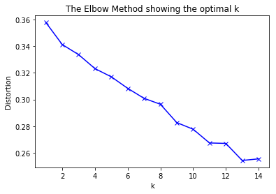

```python
# Determine optimal k (centroids) for usage in K-Means

LA_grouped_clustering = LA_grouped.drop(['Area_Name','Street'], 1)

distortions = []
K = range(1,15)
for k in K:
    kmeanModel = KMeans(n_clusters=k).fit(LA_grouped_clustering)
    kmeanModel.fit(LA_grouped_clustering)
    distortions.append(sum(np.min(cdist(LA_grouped_clustering, kmeanModel.cluster_centers_, 'euclidean'), axis=1)) / LA_grouped_clustering.shape[0])

# Plot the elbow
plt.plot(K, distortions, 'bx-')
plt.xlabel('k')
plt.ylabel('Distortion')
plt.title('The Elbow Method showing the optimal k')
plt.show()
```

```python
print("Best optimal k would be ",13)
```

```
Best optimal k would be  13
```

```python
# set number of clusters and cluster using K-Means
kclusters = 13

LA_grouped_clustering = LA_grouped.drop(['Area_Name','Street'], 1)

# run k-means clustering
kmeans = KMeans(init = "k-means++", n_clusters=kclusters, random_state=0).fit(LA_grouped_clustering)

# check cluster labels generated for each row in the dataframe
kmeans.labels_[0:10]
```

```
array([1, 2, 7, 1, 1, 5, 1, 1, 5, 1], dtype=int32)
```

```python
# add clustering labels
neighborhoods_venues_sorted2=neighborhoods_venues_sorted.copy()
neighborhoods_venues_sorted2.insert(0, 'Cluster_Labels', kmeans.labels_)

# Join la_collision_fmt3 with common venue data to add latitude/longitude for each area
LA_merged = la_collision_fmt3[['Area_Name','Address','Latitude','Longitude']]
LA_merged.rename(columns={'Address':'Street'},inplace=True)

Area_df=pd.DataFrame(LA_merged.Area_Name.unique())
Area_df['Division_Num']=np.arange(1,22)
Area_df.columns=['Area_Name','Division_Num']
LA_merged = LA_merged.join(Area_df.set_index(['Area_Name']), on=['Area_Name'])
LA_merged = LA_merged.join(neighborhoods_venues_sorted2.set_index(['Area_Name','Street']), on=['Area_Name','Street'])

LA_merged=LA_merged.dropna().reset_index(drop=True)
LA_merged["Cluster_Labels"]=LA_merged["Cluster_Labels"].astype(int)
LA_merged["Latitude"]=LA_merged["Latitude"].astype(float)
LA_merged["Longitude"]=LA_merged["Longitude"].astype(float)

print(LA_merged['Cluster_Labels'].value_counts().sort_index())
LA_merged.head()
```

```
0      4
1     73
2      3
3      1
4      1
5      4
6      2
7     11
8      1
9      1
10     1
11     1
12     2
Name: Cluster_Labels, dtype: int64
```

|  | Area_Name | Street | Latitude | Longitude | Division_Num | Cluster_Labels | 1st Most Common Venue | 2nd Most Common Venue | 3rd Most Common Venue | 4th Most Common Venue | 5th Most Common Venue | 6th Most Common Venue | 7th Most Common Venue | 8th Most Common Venue | 9th Most Common Venue | 10th Most Common Venue |
| --- | --- | --- | --- | --- | --- | --- | --- | --- | --- | --- | --- | --- | --- | --- | --- | --- |
| 0 | Southwest | 1000 W 39TH ST | 34.0155 | -118.2915 | 1 | 1 | Science Museum | Museum | History Museum | Aquarium | Fast Food Restaurant | Food Court | Pizza Place | Coffee Shop | Pool | Park |
| 1 | Southwest | 1000 W 43RD ST | 34.0055 | -118.2915 | 1 | 1 | Chinese Restaurant | Mobile Phone Shop | Bakery | Pet Store | Grocery Store | Falafel Restaurant | Electronics Store | Ethiopian Restaurant | Event Space | Yoga Studio |
| 2 | Southwest | 1000 W MARTIN LUTHER KING JR BL | 34.0145 | -118.2937 | 1 | 1 | Pizza Place | Fast Food Restaurant | Cosmetics Shop | Park | Donburi Restaurant | Sandwich Place | Shoe Store | Sports Bar | Pool | Nail Salon |
| 3 | Southwest | 1000 W MARTIN LUTHER KING JR BL | 34.0109 | -118.2915 | 1 | 1 | Pizza Place | Fast Food Restaurant | Cosmetics Shop | Park | Donburi Restaurant | Sandwich Place | Shoe Store | Sports Bar | Pool | Nail Salon |
| 4 | Southwest | 1000 W MARTIN LUTHER KING JR BL | 34.0109 | -118.2915 | 1 | 1 | Pizza Place | Fast Food Restaurant | Cosmetics Shop | Park | Donburi Restaurant | Sandwich Place | Shoe Store | Sports Bar | Pool | Nail Salon |

```python
# Define function to grab public transport venues with in 500 meters of collision locations

transport_catg_id = '4d4b7105d754a06379d81259'    # root category id for Travel & transport

LIMIT=100
radius=500

def getTransportVenues(areaname, street, latitude, longitude, cluster_label, raduis=500):

    transport_list=[]
    for aname, street, lat, lng, cluster in zip(areaname, street, latitude, longitude, cluster_label):
        # print(aname, street, lat, lng, cluster)

        # create the API request URL
        url = 'https://api.foursquare.com/v2/venues/search?&client_id={}&client_secret={}&v={}&ll={},{}&categoryId={}&radius={}&limit={}'.format(
            CLIENT_ID,
            CLIENT_SECRET,
            VERSION,
            lat,
            lng,
            transport_catg_id,
            radius,
            LIMIT)

        # make the GET request
        results = requests.get(url).json()['response']['venues']

        # return only relevant information for each nearby venue
        transport_list.append([(
            aname,
            street,
            lat,
            lng,
            cluster,
            v['name'],
            v['categories'][0]['name'],
            v['location']['distance'],
            v['location']['lat'],
            v['location']['lng'],
            v['categories'][0]["id"]
            ) for v in results])

    nearby_transport_venues = pd.DataFrame([item for transport_list in transport_list for item in transport_list])
    nearby_transport_venues.columns = ['Area_Name',
                  'Street',
                  'Collision_Latitude',
                  'Collision_Longitude',
                  'Cluster_Label',
                  'Transport_Venue',
                  'Transport_Venue_Category',
                  'Transport_Venue_Distance',
                  'Transport_Venue_Latitude',
                  'Transport_Venue_Longitude',
                  'Transport_Category_Id'
                  ]

    return(nearby_transport_venues)
```

```python
LA_Transport_venues = getTransportVenues(LA_merged['Area_Name'],
                   LA_merged['Street'],
                   LA_merged['Latitude'],
                   LA_merged['Longitude'],
                   LA_merged['Cluster_Labels']
                  )
```

```python
print(LA_Transport_venues.shape)
LA_Transport_venues.head()
```

```
(1165, 11)
```

|  | Area_Name | Street | Collision_Latitude | Collision_Longitude | Cluster_Label | Transport_Venue | Transport_Venue_Category | Transport_Venue_Distance | Transport_Venue_Latitude | Transport_Venue_Longitude | Transport_Category_Id |
| --- | --- | --- | --- | --- | --- | --- | --- | --- | --- | --- | --- |
| 0 | Southwest | 1000 W 39TH ST | 34.0155 | -118.2915 | 1 | Expo / Vermont Metro Station | Light Rail Station | 305 | 34.018241 | -118.291541 | 4bf58dd8d48988d1fc931735 |
| 1 | Southwest | 1000 W 39TH ST | 34.0155 | -118.2915 | 1 | Metro 754 MLK And Vermont Bus Stop | Bus Line | 449 | 34.011461 | -118.291520 | 4bf58dd8d48988d12b951735 |
| 2 | Southwest | 1000 W 39TH ST | 34.0155 | -118.2915 | 1 | Natural History Museum (NHM) Metro Bus 102/550 | Bus Stop | 388 | 34.018072 | -118.288654 | 52f2ab2ebcbc57f1066b8b4f |
| 3 | Southwest | 1000 W 39TH ST | 34.0155 | -118.2915 | 1 | Martin Luther King, Jr. Boulevard at Vermont A... | Intersection | 516 | 34.010863 | -118.291551 | 52f2ab2ebcbc57f1066b8b4c |
| 4 | Southwest | 1000 W 39TH ST | 34.0155 | -118.2915 | 1 | USC Tram Stop - Viterbi Engineering | Bus Line | 611 | 34.020065 | -118.287820 | 4bf58dd8d48988d12b951735 |

```python
# Below are the Foursquare category ids for public transport like bus stops, metro stations, light rail stations etc

#Travel & transport 4d4b7105d754a06379d81259 root category id
#bus stop 52f2ab2ebcbc57f1066b8b4f
#Bus line 4bf58dd8d48988d12b951735
#Bus station 4bf58dd8d48988d1fe931735
#Cable car 52f2ab2ebcbc57f1066b8b50
#Airport 4bf58dd8d48988d1ed931735
#Metro Station 4bf58dd8d48988d1fd931735
#Light Rail 4bf58dd8d48988d1fc931735
#Intersection 52f2ab2ebcbc57f1066b8b4c
#Tram station 52f2ab2ebcbc57f1066b8b51
#Train station 4bf58dd8d48988d129951735
#Taxi Stand 53fca564498e1a175f32528b

public_transport_catg_ids = ['52f2ab2ebcbc57f1066b8b4f', '4bf58dd8d48988d12b951735', '4bf58dd8d48988d1fe931735',
                             '52f2ab2ebcbc57f1066b8b50', '4bf58dd8d48988d1ed931735', '4bf58dd8d48988d1fd931735',
                             '4bf58dd8d48988d1fc931735', '52f2ab2ebcbc57f1066b8b4c', '52f2ab2ebcbc57f1066b8b51',
                             '4bf58dd8d48988d129951735', '53fca564498e1a175f32528b']

LA_Public_Transport_venues = LA_Transport_venues[(LA_Transport_venues.Transport_Category_Id.isin(public_transport_catg_ids))].drop_duplicates(subset=['Transport_Venue','Transport_Venue_Category']).reset_index(drop=True)
LA_Public_Transport_venues.shape
```

```
(289, 11)
```

```python
# create map for clustered collision data
map_clusters = folium.Map(location=[34.052235, -118.243683], zoom_start=11)

# set color scheme for the clusters
x = np.arange(kclusters)
ys = [i + x + (i*x)**2 for i in range(kclusters)]
colors_array = cm.rainbow(np.linspace(0, 1, len(ys)))
rainbow = [colors.rgb2hex(i) for i in colors_array]

# add choropleth layer to the map showing LAPD divisions
map_clusters.choropleth(
    geo_data=LA_geo,
    data=LA_merged,
    columns=['Area_Name','Division_Num'],
    key_on='feature.properties.name',
#    fill_color='PuRd',
#    fill_color='BuPu',
#    fill_color='YlGnBu',
    fill_color='YlOrRd',
#    fill_color='YlGn',
    fill_opacity=0.3,
    line_opacity=0.2,
    legend_name='LAPD Divisions'
)

# add Collision markers to the map
markers_colors = []
for lat, lon, poi, cluster in zip(LA_merged['Latitude'], LA_merged['Longitude'], LA_merged['Area_Name'], LA_merged['Cluster_Labels'].astype(int)):
    label = folium.Popup(str(poi) + ' Cluster ' + str(cluster), parse_html=True)
    folium.CircleMarker(
        [lat, lon],
        radius=5,
        popup=label,
        color=rainbow[cluster-1],
        fill=True,
        fill_color=rainbow[cluster-1],
        fill_opacity=0.7).add_to(map_clusters)

# add Public transport markers to the map
mc = MarkerCluster()
for lat, lon, transport, catg, dist in zip(LA_Public_Transport_venues['Transport_Venue_Latitude'],
                                  LA_Public_Transport_venues['Transport_Venue_Longitude'],
                                  LA_Public_Transport_venues['Transport_Venue'],
                                  LA_Public_Transport_venues['Transport_Venue_Category'],
                                  LA_Public_Transport_venues['Transport_Venue_Distance']):
    poplabel = folium.Popup(catg + ' - ' + transport + ' - ' + str(dist) + ' M away', parse_html=True)
    mc.add_child(folium.Marker(location=[lat,  lon],
                 popup=poplabel))

map_clusters.add_child(mc)

map_clusters
```

[interactive chart not shown]

#### Top 5 recommended venue categories and all transport venues per each collision street in each cluster

##### To navigate back to results section Click Here

```python
# print top 5 common venues among each collision street in each cluster
LA_merged_no_transport = pd.DataFrame(columns=['Area_Name', 'Street'])
print('Cluster', 'Count', '\n'+ str(LA_merged['Cluster_Labels'].value_counts().sort_index()),
      '\n\nTop 5 recommended venue categories and all transport venues per each collision street (with in 500 meters) in each cluster \n')
for cluster in LA_merged.Cluster_Labels.sort_values().unique():
    print("---- Cluster",cluster,"----")
    for aname, st, v1, v2, v3, v4, v5 in zip(LA_merged[(LA_merged['Cluster_Labels']==cluster)]['Area_Name'],
                         LA_merged[(LA_merged['Cluster_Labels']==cluster)]['Street'],
                         LA_merged[(LA_merged['Cluster_Labels']==cluster)]['1st Most Common Venue'],
                         LA_merged[(LA_merged['Cluster_Labels']==cluster)]['2nd Most Common Venue'],
                         LA_merged[(LA_merged['Cluster_Labels']==cluster)]['3rd Most Common Venue'],
                         LA_merged[(LA_merged['Cluster_Labels']==cluster)]['4th Most Common Venue'],
                         LA_merged[(LA_merged['Cluster_Labels']==cluster)]['5th Most Common Venue']
                        ):
        df_tmp = LA_Public_Transport_venues[(LA_Public_Transport_venues['Cluster_Label']==cluster) &
                                             (LA_Public_Transport_venues['Area_Name']==aname) &
                                             (LA_Public_Transport_venues['Street']==st)
                                            ].copy()
        df_tmp.sort_values(by='Transport_Venue_Distance',inplace=True)
        print('LAPD Division','|','Collision Street \n' +
              '-------------',' ','----------------','\n',
              aname, '   | ',' '.join(st.split()),'\n',
              '1st Most Common Venue',':',v1,'\n',
              '2nd Most Common Venue',':',v2,'\n',
              '3rd Most Common Venue',':',v3,'\n',
              '4th Most Common Venue',':',v4,'\n',
              '5th Most Common Venue',':',v5
             )
        print('\n Public transport venues near to this collision street')
        if df_tmp.shape[0]==0:
            LA_merged_no_transport=LA_merged_no_transport.append(pd.DataFrame([[aname, st]],columns=['Area_Name', 'Street']),ignore_index=True)
            print(' ','-----None-----')
        for catg, transport, dist in zip(df_tmp['Transport_Venue_Category'],
                                         df_tmp['Transport_Venue'],
                                         df_tmp['Transport_Venue_Distance']
                                        ):
            print(' ',catg,'|',transport,'|',dist,'Metres')
        print('\n')
```

```
Cluster Count
0      4
1     73
2      3
3      1
4      1
5      4
6      2
7     11
8      1
9      1
10     1
11     1
12     2
Name: Cluster_Labels, dtype: int64

Top 5 recommended venue categories and all transport venues per each collision street (with in 500 meters) in each cluster

---- Cluster 0 ----
LAPD Division | Collision Street
-------------   ----------------
 Southeast    |  100 E CENTURY BL
 1st Most Common Venue : Hotel
 2nd Most Common Venue : Fast Food Restaurant
 3rd Most Common Venue : Liquor Store
 4th Most Common Venue : Gym / Fitness Center
 5th Most Common Venue : Mobile Phone Shop

 Public transport venues near to this collision street
  -----None-----


LAPD Division | Collision Street
-------------   ----------------
 Southeast    |  100 E COLDEN AV
 1st Most Common Venue : Mobile Phone Shop
 2nd Most Common Venue : Wine Bar
 3rd Most Common Venue : Liquor Store
 4th Most Common Venue : Gym / Fitness Center
 5th Most Common Venue : Yoga Studio
```

[output cut: 1632 more lines]

```
  Bus Line | 232 Bus Stop | 384 Metres


LAPD Division | Collision Street
-------------   ----------------
 Foothill    |  10400 GLENOAKS BL
 1st Most Common Venue : American Restaurant
 2nd Most Common Venue : Bus Station
 3rd Most Common Venue : Yoga Studio
 4th Most Common Venue : Drugstore
 5th Most Common Venue : Fish Market

 Public transport venues near to this collision street
  Bus Station | Metro Bus Division 15 | 444 Metres
  Bus Line | Metro Bus | 486 Metres
```

```python
# Format data to print top recommended venue categories per each cluster regardless of LAPD Division
LA_grouped2 = LA_grouped.join(neighborhoods_venues_sorted2.set_index(['Area_Name','Street']), on=['Area_Name','Street'])
LA_grouped2 = LA_grouped2.drop(['Area_Name','Street','1st Most Common Venue','2nd Most Common Venue','3rd Most Common Venue',
                               '4th Most Common Venue','5th Most Common Venue','6th Most Common Venue',
                               '7th Most Common Venue','8th Most Common Venue','9th Most Common Venue',
                               '10th Most Common Venue'],axis=1)
LA_grouped2 = LA_grouped2.groupby(['Cluster_Labels']).mean()
print(LA_grouped2.shape)
LA_grouped2.head(20)
```

```
(13, 253)
```

| Cluster_Labels | ATM | Accessories Store | Adult Boutique | Airport | Airport Lounge | Airport Service | Airport Terminal | American Restaurant | Amphitheater | Antique Shop | Aquarium | Arcade | Argentinian Restaurant | Art Gallery | Arts & Crafts Store | Asian Restaurant | Australian Restaurant | Auto Garage | Automotive Shop | BBQ Joint | Bagel Shop | Bakery | Bank | Bar | Baseball Field | Baseball Stadium | Basketball Court | Beach | Beer Garden | … |
| --- | --- | --- | --- | --- | --- | --- | --- | --- | --- | --- | --- | --- | --- | --- | --- | --- | --- | --- | --- | --- | --- | --- | --- | --- | --- | --- | --- | --- | --- | --- |
| 0 | 0.000000 | 0.000000 | 0.000000 | 0.00000 | 0.000000 | 0.00000 | 0.000000 | 0.000000 | 0.000000 | 0.000000 | 0.000000 | 0.000000 | 0.000000 | 0.000000 | 0.000000 | 0.000000 | 0.00000 | 0.000000 | 0.000000 | 0.000000 | 0.000000 | 0.000000 | 0.00000 | 0.000000 | 0.000000 | 0.000000 | 0.000000 | 0.00000 | 0.00000 | … |
| 1 | 0.001972 | 0.002578 | 0.000698 | 0.00018 | 0.004562 | 0.00528 | 0.000718 | 0.010474 | 0.000579 | 0.000911 | 0.001157 | 0.002753 | 0.000411 | 0.007538 | 0.001852 | 0.008663 | 0.00026 | 0.000651 | 0.005208 | 0.001772 | 0.005873 | 0.023347 | 0.00571 | 0.011805 | 0.006688 | 0.004051 | 0.001462 | 0.00026 | 0.00054 | … |
| 2 | 0.000000 | 0.000000 | 0.000000 | 0.00000 | 0.000000 | 0.00000 | 0.000000 | 0.000000 | 0.000000 | 0.000000 | 0.000000 | 0.000000 | 0.000000 | 0.000000 | 0.000000 | 0.000000 | 0.00000 | 0.000000 | 0.000000 | 0.000000 | 0.000000 | 0.000000 | 0.00000 | 0.000000 | 0.000000 | 0.000000 | 0.000000 | 0.00000 | 0.00000 | … |
| 3 | 0.000000 | 0.000000 | 0.000000 | 0.00000 | 0.000000 | 0.00000 | 0.000000 | 0.000000 | 0.000000 | 0.000000 | 0.000000 | 0.000000 | 0.000000 | 0.000000 | 0.000000 | 0.000000 | 0.00000 | 0.000000 | 0.000000 | 0.000000 | 0.000000 | 0.000000 | 0.00000 | 0.000000 | 0.000000 | 0.000000 | 0.000000 | 0.00000 | 0.00000 | … |
| 4 | 0.000000 | 0.000000 | 0.000000 | 0.00000 | 0.000000 | 0.00000 | 0.000000 | 0.000000 | 0.000000 | 0.000000 | 0.000000 | 0.000000 | 0.000000 | 0.000000 | 0.000000 | 0.000000 | 0.00000 | 0.000000 | 0.000000 | 0.000000 | 0.000000 | 0.000000 | 0.00000 | 0.000000 | 0.000000 | 0.000000 | 0.000000 | 0.00000 | 0.00000 | … |
| 5 | 0.000000 | 0.000000 | 0.000000 | 0.00000 | 0.000000 | 0.00000 | 0.000000 | 0.000000 | 0.000000 | 0.000000 | 0.000000 | 0.000000 | 0.000000 | 0.000000 | 0.000000 | 0.000000 | 0.00000 | 0.000000 | 0.000000 | 0.000000 | 0.000000 | 0.000000 | 0.00000 | 0.000000 | 0.000000 | 0.000000 | 0.000000 | 0.00000 | 0.00000 | … |
| 6 | 0.000000 | 0.000000 | 0.000000 | 0.00000 | 0.000000 | 0.00000 | 0.000000 | 0.000000 | 0.000000 | 0.000000 | 0.000000 | 0.000000 | 0.000000 | 0.000000 | 0.000000 | 0.000000 | 0.00000 | 0.000000 | 0.000000 | 0.000000 | 0.000000 | 0.000000 | 0.00000 | 0.000000 | 0.000000 | 0.000000 | 0.000000 | 0.00000 | 0.00000 | … |
| 7 | 0.000000 | 0.000000 | 0.000000 | 0.00000 | 0.000000 | 0.00000 | 0.000000 | 0.011364 | 0.000000 | 0.000000 | 0.000000 | 0.000000 | 0.000000 | 0.005682 | 0.000000 | 0.005682 | 0.00000 | 0.000000 | 0.000000 | 0.000000 | 0.011364 | 0.061778 | 0.00000 | 0.005682 | 0.005682 | 0.000000 | 0.000000 | 0.00000 | 0.00000 | … |
| 8 | 0.000000 | 0.000000 | 0.000000 | 0.00000 | 0.000000 | 0.00000 | 0.000000 | 0.000000 | 0.000000 | 0.000000 | 0.000000 | 0.000000 | 0.000000 | 0.000000 | 0.000000 | 0.000000 | 0.00000 | 0.000000 | 0.000000 | 0.000000 | 0.000000 | 0.000000 | 0.00000 | 0.000000 | 0.000000 | 0.000000 | 0.000000 | 0.00000 | 0.00000 | … |
| 9 | 0.000000 | 0.000000 | 0.000000 | 0.00000 | 0.000000 | 0.00000 | 0.000000 | 0.000000 | 0.000000 | 0.000000 | 0.000000 | 0.000000 | 0.000000 | 0.000000 | 0.000000 | 0.000000 | 0.00000 | 0.000000 | 0.000000 | 0.000000 | 0.000000 | 0.000000 | 0.00000 | 0.000000 | 0.000000 | 0.000000 | 0.000000 | 0.00000 | 0.00000 | … |
| 10 | 0.000000 | 0.000000 | 0.000000 | 0.00000 | 0.000000 | 0.00000 | 0.000000 | 0.000000 | 0.000000 | 0.000000 | 0.000000 | 0.000000 | 0.000000 | 0.000000 | 0.000000 | 0.000000 | 0.00000 | 0.000000 | 0.000000 | 0.000000 | 0.000000 | 0.000000 | 0.00000 | 0.000000 | 0.000000 | 0.000000 | 0.000000 | 0.00000 | 0.00000 | … |
| 11 | 0.000000 | 0.000000 | 0.000000 | 0.00000 | 0.000000 | 0.00000 | 0.000000 | 0.000000 | 0.000000 | 0.000000 | 0.000000 | 0.000000 | 0.000000 | 0.000000 | 0.000000 | 0.000000 | 0.00000 | 0.000000 | 0.000000 | 0.000000 | 0.000000 | 0.000000 | 0.00000 | 0.000000 | 0.000000 | 0.000000 | 0.000000 | 0.00000 | 0.00000 | … |
| 12 | 0.000000 | 0.000000 | 0.000000 | 0.00000 | 0.000000 | 0.00000 | 0.000000 | 0.375000 | 0.000000 | 0.000000 | 0.000000 | 0.000000 | 0.000000 | 0.000000 | 0.000000 | 0.000000 | 0.00000 | 0.000000 | 0.000000 | 0.000000 | 0.000000 | 0.000000 | 0.00000 | 0.000000 | 0.000000 | 0.000000 | 0.000000 | 0.00000 | 0.00000 | … |

#### Top 10 recommended venue categories per each cluster during year 2018

##### To navigate back to results section Click Here

```python
print("Top 10 recommended venue categories per each cluster during year 2018\n")
for cluster in LA_grouped2.index:
    print("---- Cluster",cluster,"Venues----")
    for i in LA_grouped2.iloc[cluster].sort_values(ascending=False)[:10].index:
        print(i)
    print("\n")
```

```
Top 10 recommended venue categories per each cluster during year 2018

---- Cluster 0 Venues----
Gym / Fitness Center
Liquor Store
Mobile Phone Shop
Hotel
Wine Bar
Fast Food Restaurant
Clothing Store
Boat or Ferry
Harbor / Marina
Grocery Store


---- Cluster 1 Venues----
Coffee Shop
Fast Food Restaurant
Pizza Place
Mexican Restaurant
Convenience Store
Bakery
Sandwich Place
Thai Restaurant
Furniture / Home Store
Food Truck


---- Cluster 2 Venues----
Mexican Restaurant
Food Truck
Latin American Restaurant
Bus Line
Sandwich Place
Taco Place
Ethiopian Restaurant
Dumpling Restaurant
Duty-free Shop
Electronics Store

```

[output cut: 114 more lines]

```
Farmers Market
Farm


---- Cluster 12 Venues----
American Restaurant
Bus Station
Chinese Restaurant
Japanese Restaurant
Mobile Phone Shop
Filipino Restaurant
Fast Food Restaurant
Farmers Market
Film Studio
Dumpling Restaurant
```

```python
print("Top 10 Recommended Venue Categories among all clusters near to collision locations\n")
for i in LA_grouped2.mean().sort_values(ascending=False)[:10].index:
    print(i)
```

```
Top 10 Recommended Venue Categories among all clusters near to collision locations

Gym
Farm
Park
Mexican Restaurant
Gym / Fitness Center
Marijuana Dispensary
Food Truck
Cosmetics Shop
Dive Bar
Train Station
```

#### Collision streets which didn't have any public transport venues with in 500 meters radius from collision locations

##### To navigate back to results section Click Here

```python
print("Collision streets which doesn't have any public transport venues with in 500 meters radius from collision points")
LA_merged_no_transport=LA_merged_no_transport.drop_duplicates(subset=['Area_Name','Street']).reset_index(drop=True)
LA_merged_no_transport
```

```
Collision streets which doesn't have any public transport venues with in 500 meters radius from collision points
```

|  | Area_Name | Street |
| --- | --- | --- |
| 0 | Southeast | 100 E CENTURY BL |
| 1 | Southeast | 100 E COLDEN AV |
| 2 | Southeast | 100 W 98TH ST |
| 3 | Southwest | 1000 W MARTIN LUTHER KING JR BL |
| 4 | Van Nuys | 13700 BURBANK BL |
| 5 | Harbor | 100 N GAFFEY ST |
| 6 | Mission | 11300 N SEPULVEDA BL |
| 7 | Mission | 12800 FOOTHILL BL |
| 8 | Topanga | 20000 ROSCOE BL |
| 9 | Topanga | 20000 VENTURA BL |
| 10 | West Valley | 15600 ROYAL RIDGE RD |
| 11 | West Valley | 15900 VANOWEN ST |
| 12 | Pacific | 00 WORLD WAY |
| 13 | Pacific | 100 WORLD WY |
| 14 | Devonshire | 11000 BALBOA BL |
| 15 | 77th Street | 100 E 84TH ST |
| 16 | 77th Street | 1000 W 60TH ST |
| 17 | Newton | 100 E VERNON AV |
| 18 | West Valley | 16000 SHERMAN WY |
| 19 | 77th Street | 100 W 79TH ST |
| 20 | Southeast | 100 E 109TH PL |
| 21 | Foothill | 10100 JANETTA WY |
| 22 | Olympic | 100 S VAN NESS AV |
| 23 | Mission | 12700 SAN FERNANDO RD |
| 24 | Foothill | 10400 LAUREL CANYON BL |
| 25 | Newton | 100 E 61ST ST |
| 26 | Newton | 100 E 62ND ST |
| 27 | Newton | 100 E SLAUSON AV |
| 28 | Hollenbeck | 100 S CONCORD ST |
| 29 | Devonshire | 10200 VANALDEN AV |
| 30 | Harbor | 1000 CAPITOL DR |
| 31 | Foothill | 10300 TUJUNGA CANYON BL |
| 32 | Southeast | 100 E 92ND ST |

## Results and Discussion

As per clustering results, 100+ collisions (5 collisions per 21 LAPD divisions) have been clustered into 13 clusters.

And most recommended venue categories and all transport venues per each cluster is reported in the code block.  
Top 5 recommended venue categories and all transport venues per each collision street in each cluster  
Note:- Please note that some collision streets doesn't have any public transport venues.

And most recommended venue categories per each cluster is reported in the below code block link.  
Top 10 recommended venue categories per each cluster during year 2018

And collision streets which didnt have public transport venues with in 500 meters radius from collision locations.  
Collision streets which didn't have any public transport venues with in 500 meters radius from collision locations

## Conclusion

As per analyzed results, stakeholder LA department of transportation can become aware of all collision locations and near by recommended venues, which are causing collisions inadvertently. Public transport venues with in 500 meters of collision locations are also listed, so that stakeholder can make better decision, if any new public transport venues are needed to setup near to most frequent collision locations. By doing so, LA residents\tourists can make avail of public transport venues to navigate with in the city, there by avoiding traffic congestions and minimizing collisions and thus saving people's lives.